# Life Expectancy

- Show All Code
- Hide All Code
- View Source

Author

Gunardi

Published

June 11, 2023

## 1 Introduction

The goal is to answer the following questions:

1. What is the life expectancy for people with your age? I was born in year 1988. **Answer**: Section 6
2. What are the survival function for people born in year 2000? **Answer**: Section 7.5

## 2 Importing Python library

```python
import numpy as np
import pandas as pd
import plotly.express as px
from itertools import product
from scipy import integrate
import scipy
import matplotlib.pyplot as plt
```

## 3 Read the data

The dataset has the following shape:

```python
raw_data = pd.read_csv("DAV2008T.csv", sep=";")
raw_data.shape
```

```
(122, 16)
```

Get all column names:

```python
raw_data.columns
```

```
Index(['Alter', 'A', 'E', 'C', 'B', 'F', 'D', 'G', 'M', 'J', 'H', 'N', 'K',
       'I', 'O', 'L'],
      dtype='object')
```

## 4 Filter data

Based on [this document](https://aktuar.de/Dateien_extern/DAV/LV/UT_LV_14.pdf) on page 38, we need only the following data from columns:

- column ‘Alter’ shows the age
- column ‘A’ is the qx, which is probability of mortality in first order (mortality rate).

```python
data = raw_data.loc[:,['Alter', 'A']]
data.head()
```

|  | Alter | A |
| --- | --- | --- |
| 0 | 0 | 0.006113 |
| 1 | 1 | 0.000423 |
| 2 | 2 | 0.000343 |
| 3 | 3 | 0.000275 |
| 4 | 4 | 0.000220 |

Let’s give the columns more appropriate names:

```python
data.rename(columns={'Alter': "age", 'A': "qx"}, inplace=True)
data.head()
```

|  | age | qx |
| --- | --- | --- |
| 0 | 0 | 0.006113 |
| 1 | 1 | 0.000423 |
| 2 | 2 | 0.000343 |
| 3 | 3 | 0.000275 |
| 4 | 4 | 0.000220 |

## 5 Visualize data

Visualize f curve (density function for mortality):

```python
fig = px.line(data, y="qx", x="age", hover_data=['age', 'qx'], labels=dict(age="Age", qx="f"))
fig.show()
```

[interactive chart not shown]

Get survival rate (S):

```python
S = 1
data.loc[:, "S"] = 0

for i in range(len(data)):
  S = S*(1-data.loc[i, 'qx'])
  data.loc[i, 'S'] = S
```

Visualize survival rate:

```python
fig = px.line(data, y="S", x="age", hover_data=['age'], labels=dict(age="Age", S="Survival Rate"))
fig.add_hline(y=0.5, line_dash="solid", row=1, col=1, line_color="#000000", line_width=1)
fig.show()
```

[interactive chart not shown]

Based on the graph above, the life expectancy is:

```python
data.iloc[(data['S']-0.5).abs().argsort()[:1]]
```

|  | age | qx | S |
| --- | --- | --- | --- |
| 76 | 76 | 0.067433 | 0.504283 |

We define life expectancy as the age after which the survival rate < 0.5. More explanation can be found [here](https://www.ncbi.nlm.nih.gov/books/NBK424557/).

Get F or failure rate:

```python
data.loc[:, "F"] = 1 - data.loc[:, "S"]
```

Visualize F:

```python
fig = px.line(data, y="F", x="age", hover_data=['age'], labels=dict(age="Age", F="Failure Rate"))
fig.add_hline(y=0.5, line_dash="solid", row=1, col=1, line_color="#000000", line_width=1)
fig.show()
```

[interactive chart not shown]

Get f or failure density:

```python
data.loc[:, "f"] = data.loc[:, "F"].diff()
```

Visualize f:

```python
fig = px.line(data, y="f", x="age", hover_data=['age'], labels=dict(age="Age", f="Failure Density"))
fig.show()
```

[interactive chart not shown]

## 6 What is my life expectancy?

I am born in 1988 and by the time of writting, it is 2023. My age is 35 years old. For further calculation, we interested in the failure density starting from 35 years old.

Let’s see the failure density graph after 35 years old:

```python
fig = px.line(data.loc[data['age'] >= 35], y="f", x="age", hover_data=['age'], labels=dict(age="Age", f="Failure Density"))
fig.show()
```

[interactive chart not shown]

Find my life expectancy by integrating the area below the graph until it approaches 0.5:

```python
x = list(data.loc[data['age'] >= 35].age)
y = list(data.loc[data['age'] >= 35].f)

for i in range(len(x)):
  current_x = x[: i+1]
  current_y = y[: i+1]
  area = integrate.simpson(current_y, current_x)
  if area >= 0.5:
    break
print("My life expectancy is {}".format(current_x[-1]))
```

```
My life expectancy is 78
```

Let’s visualize my survival rate:

```python
x = list(data.loc[data['age'] >= 35].age)
y = list(data.loc[data['age'] >= 35].f)
my_failure_rate = []
my_life_expectancy = 0

executed = False

for i in range(len(x)):
  current_x = x[: i+1]
  current_y = y[: i+1]
  area = integrate.simpson(current_y, current_x)
  my_failure_rate.append(area)
  if area >= 0.5 and not executed:
    my_life_expectancy = current_x[-1]
    executed = True

my_survival = pd.DataFrame({"age": x, "failure_rate": my_failure_rate})
my_survival.loc[:, "survival_rate"] = 1 - my_survival.loc[:, "failure_rate"]

fig = px.line(my_survival, y="survival_rate", x="age", hover_data=['age'], labels=dict(age="Age", survival_rate="My Survival Rate"))
fig.add_hline(y=0.5, line_dash="solid", row=1, col=1, line_color="#000000", line_width=1)
fig.show()
```

[interactive chart not shown]

## 7 Survival function

In the following section, we want to find the survival function for people born in year 2000 and still alive in 2023.

To do that we need to fit the relevant data for this group to the following distributions:

- Exponential
- Weibull: Scipy’s `weibull_min` function is used instead of `weibull_max`, because the x value (`age`) are positive.
- Log-normal

### 7.1 Preparing and visualising data

View the data:

```python
x = list(data.loc[data['age'] >= 23].age)
y = list(data.loc[data['age'] >= 23].f)
failure_rate = []
life_expectancy = 0

executed = False

for i in range(len(x)):
  current_x = x[: i+1]
  current_y = y[: i+1]
  area = integrate.simpson(current_y, current_x)
  failure_rate.append(area)
  if area >= 0.5 and not executed:
    my_life_expectancy = current_x[-1]
    executed = True

survival_2023 = pd.DataFrame({"age": x, "failure_rate": failure_rate})
survival_2023.loc[:, "survival_rate"] = 1 - survival_2023.loc[:, "failure_rate"]

fig = px.line(survival_2023, y="survival_rate", x="age", hover_data=['age'], labels=dict(age="Age", survival_rate="Survival Rate"), title="Survival rate for 23 years old man in year 2023")
fig.add_hline(y=0.5, line_dash="solid", row=1, col=1, line_color="#000000", line_width=1)
fig.show()
```

[interactive chart not shown]

Prepare survival function for `exponential`, `weibull` and `lognorm` distributions:

```python
# sf: survival function
def sf_exponential(x, loc=0, scale=1):
  return scipy.stats.expon.sf(x, loc, scale)

def sf_weibull(x, c, loc=0, scale=1):
  return scipy.stats.weibull_min.sf(x, c, loc, scale)

def sf_lognorm(x, s, loc=0, scale=1):
  return scipy.stats.lognorm.sf(x, s, loc, scale)
```

### 7.2 Curve fit data to `exponential` distribution

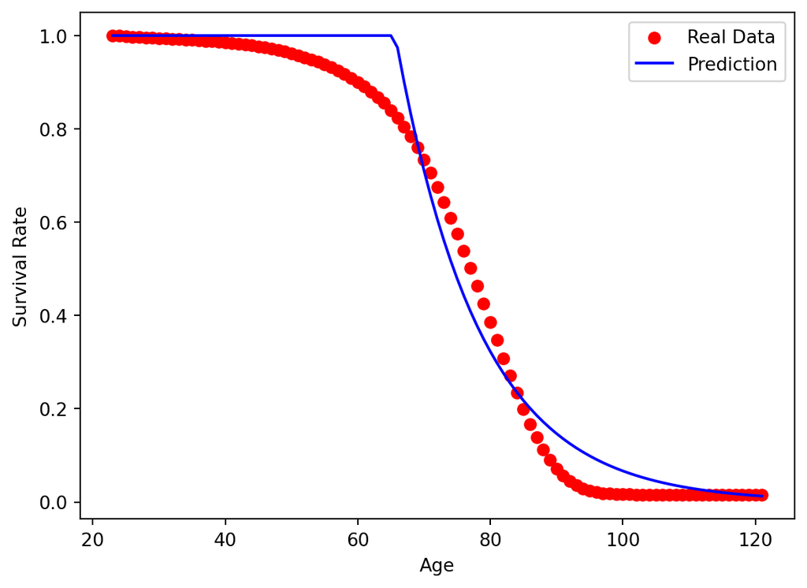

```python
popt, pcov = scipy.optimize.curve_fit(sf_exponential, survival_2023.age, survival_2023.survival_rate)

plt.scatter(survival_2023.age, survival_2023.survival_rate, label='Real Data', c='r')

pred = sf_exponential(survival_2023.age, *popt)

plt.plot(survival_2023.age, pred, 'b-', label="Prediction")

plt.xlabel('Age')
plt.ylabel('Survival Rate')
plt.legend()
plt.show()
```

### 7.3 Curve fit data to `weibull` distribution

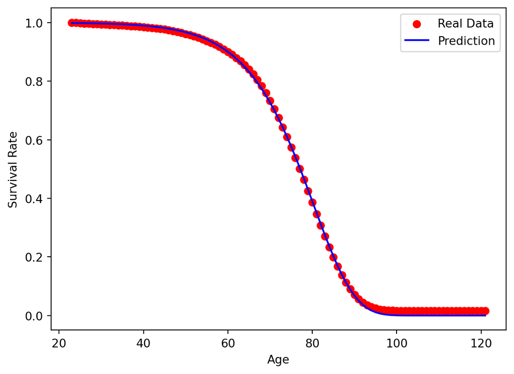

```python
popt_weibull, pcov = scipy.optimize.curve_fit(sf_weibull, survival_2023.age, survival_2023.survival_rate)

plt.scatter(survival_2023.age, survival_2023.survival_rate, label='Real Data', c='r')

pred = sf_weibull(survival_2023.age, *popt_weibull)

plt.plot(survival_2023.age, pred, 'b-', label="Prediction")

plt.xlabel('Age')
plt.ylabel('Survival Rate')
plt.legend()
plt.show()
```

### 7.4 Curve fit data to `lognorm` distribution

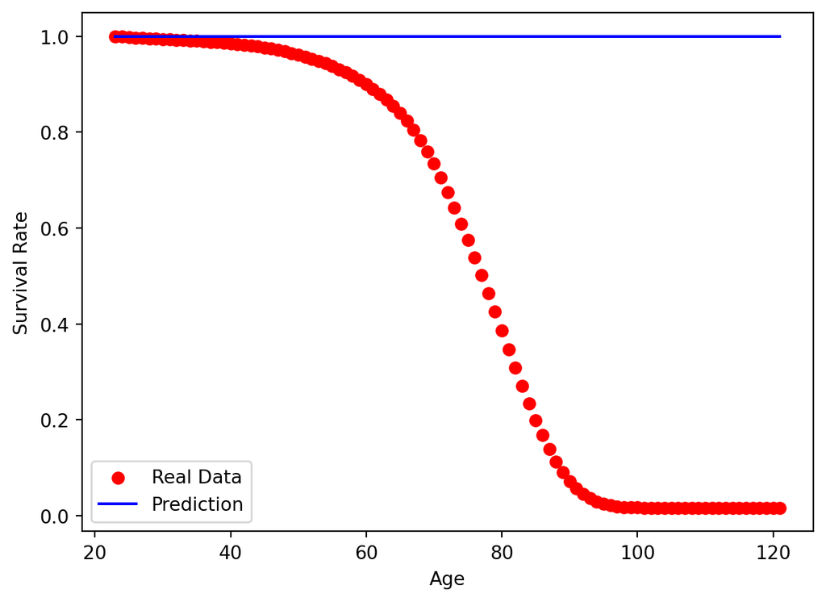

```python
popt, pcov = scipy.optimize.curve_fit(sf_lognorm, survival_2023.age, survival_2023.survival_rate)

plt.scatter(survival_2023.age, survival_2023.survival_rate, label='Real Data', c='r')

pred = sf_lognorm(survival_2023.age, *popt)

plt.plot(survival_2023.age, pred, 'b-', label="Prediction")

plt.xlabel('Age')
plt.ylabel('Survival Rate')
plt.legend()
plt.show()
```

### 7.5 Summary

1. From the last 3 graphs, `weibbull` distribution is obviously the best distribution to fit our dataset.
2. The survival function for people with age 23 in year 2023 is:

$$\Huge
S(age) = e^{-(\frac{age-loc}{scale})^c}$$

where:

```python
print("c, loc and scale = {:.2f}, {:.2f}, {:.2f}".format(popt_weibull[0], popt_weibull[1], popt_weibull[2]))
```

```
c, loc and scale = 37.84, -275.27, 355.85
```

**Proof**: The following graph shows the output of preceeding function, which is identical to the Section 7.3.

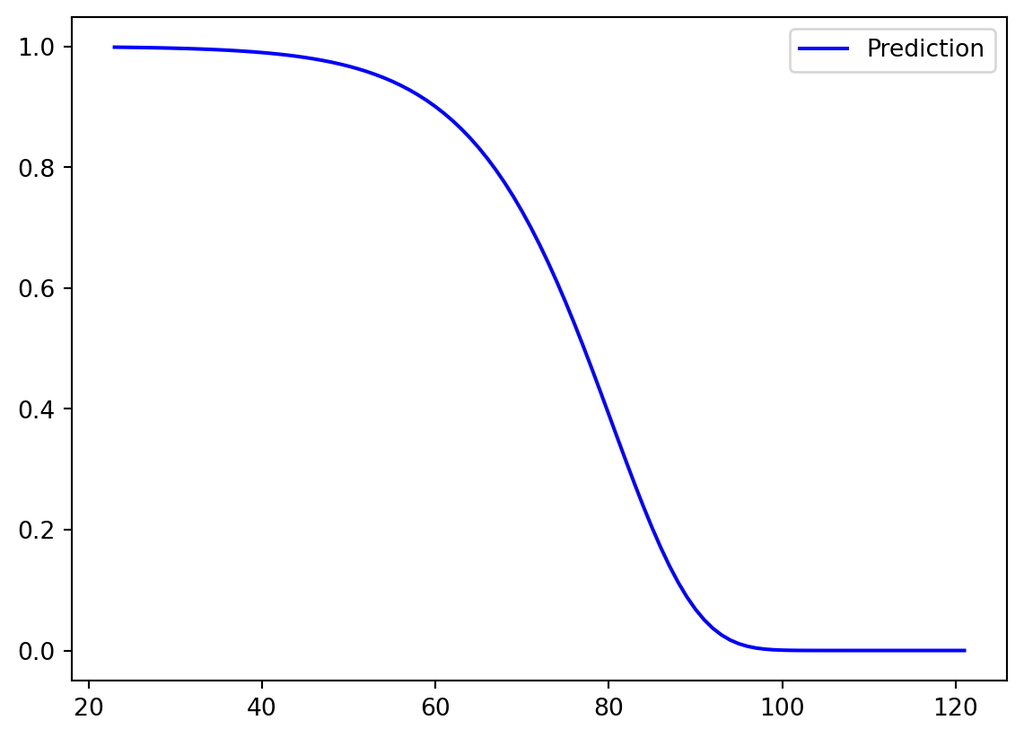

```python
c, loc, scale = [*popt_weibull]
x = survival_2023.age

pred = np.exp(-((x-loc)/scale)**c)
plt.plot(x, pred, 'b-', label="Prediction")

plt.legend()
plt.show()
```